# Statistical Inference - Course Project - Part 2

Philip Mateescu

November 18, 2015

# The Effect of Vitamin C on Tooth Growth in Guinea Pigs

## Summary

We will analyze a dataset containing the length of odontoblasts (teeth) in each of 10 guinea pigs at each of three dose levels of Vitamin C (0.5, 1, and 2 mg) with each of two delivery methods (orange juice or ascorbic acid).

This source of this dataset is the paper called [The Growth of the Odontoblasts of the Incisor Tooth as a Criterion of the Vitamin C Intake of the Guinea Pig](http://jn.nutrition.org/content/33/5/491.full.pdf) by E. W. Crampton, published in 1946, and cited in the [Statistics of Bioassay](http://onlinelibrary.wiley.com/doi/10.1002/jps.3030420425/abstract) by C. I. Bliss publised by the Academic Press Inc in 1953.

The dataset contains 60 observations of 3 variables:

1. `len` - tooth length; numeric
2. `supp` - supplement type, *VC* - ascorbic acid, or *OJ* - orange juice; factor.
3. `dose` - dose in milligrams; numeric, discrete: 0.5, 1, or 2 mg

Here is a sample of the dataset:

```r
kable(ToothGrowth[c(10:13,50:52),], caption = 'T1. Sample Data')
```

T1. Sample Data

|  | len | supp | dose |
| --- | --- | --- | --- |
| 10 | 7.0 | VC | 0.5 |
| 11 | 16.5 | VC | 1.0 |
| 12 | 16.5 | VC | 1.0 |
| 13 | 15.2 | VC | 1.0 |
| 50 | 27.3 | OJ | 1.0 |
| 51 | 25.5 | OJ | 2.0 |
| 52 | 26.4 | OJ | 2.0 |

## Comparison of Tooth Growth

First let’s examine the data through a box plot.

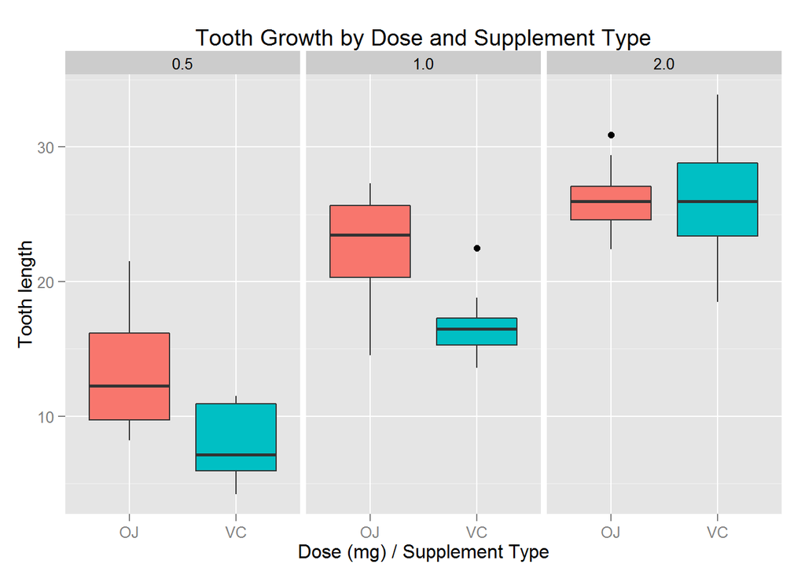

```r
ggplot(data=ToothGrowth, aes(y=len, x=supp, fill=supp)) +
    geom_boxplot() +
    facet_wrap(~dose) +
    labs(title="Tooth Growth by Dose and Supplement Type", x='Dose (mg) / Supplement Type', y='Tooth length') +
    guides(fill=guide_legend('Supplement Type')) + theme(legend.position = "none")
```

We immediately notice that there seems to be a positive correlation between the dose type and the growth.

There is some obvious variance in the data. Let’s examine a few questions we might have.

### How much variance in the growth can be attributed to the supplement type?

To answer this question, we will examine the *t-statistic* and the *p-value* for each length by supplement, for each individual dose. The observations are obviously not paired, and from the chart above we can tell the variance between the sets of observations are not equal.

```r
mkci <- function(ttestval) {
    paste('[ ', round(ttestval$conf.int[1], 4), ', ', round(ttestval$conf.int[2], 4), ' ]', sep='')
}
dose.test <- function(dose) {
    dose.set <- ToothGrowth[which(ToothGrowth$dose == dose), c('len', 'supp')]
    t.test(len ~ supp, data=dose.set, paired = F, var.equal = F)
}
d05 <- dose.test(0.5)
d1 <- dose.test(1)
d2 <- dose.test(2)

df <- data.frame(
    dose=c(0.5, 1, 2),
    t.statistic=c(d05$statistic, d1$statistic, d2$statistic),
    p.value=c(d05$p.value, d1$p.value, d2$p.value),
    conf.int=c(mkci(d05), mkci(d1), mkci(d2))
)
colnames(df) <- c('Dose', 't-statistic', 'p-value', '95% Confidence Interval')
kable(df, caption = 'T2. Supplement Effect on Growth')
```

T2. Supplement Effect on Growth

| Dose | t-statistic | p-value | 95% Confidence Interval |
| --- | --- | --- | --- |
| 0.5 | 3.1697328 | 0.0063586 | [ 1.7191, 8.7809 ] |
| 1.0 | 4.0327696 | 0.0010384 | [ 2.8021, 9.0579 ] |
| 2.0 | -0.0461361 | 0.9638516 | [ -3.7981, 3.6381 ] |

## How much variance can be attributed to the dose?

We will now perform the same investigation as above, except this time we will investigate the effect of the various doses by supplement type.

```r
supp.test <- function(supp, dose) {
    supp.set <- ToothGrowth[which(ToothGrowth$supp == supp & ToothGrowth$dose %in% dose), c('len', 'dose')]
    t.test(len ~ dose, data=supp.set, paired = F, var.equal = F)
}
d.oj.5vs1 <- supp.test('OJ', c(0.5, 1))
d.oj.1vs2 <- supp.test('OJ', c(1, 2))
d.vc.5vs1 <- supp.test('VC', c(0.5, 1))
d.vc.1vs2 <- supp.test('VC', c(1, 2))

df <- data.frame(
    supp.dose=c('OJ 0.5 vs 1mg', 'OJ 1 vs 2mg', 'VC 0.5 vs 1mg', 'VC 1 vs 2mg'),
    t.statistic=c(d.oj.5vs1$statistic, d.oj.1vs2$statistic, d.vc.5vs1$statistic, d.vc.1vs2$statistic),
    p.value=c(d.oj.5vs1$p.value, d.oj.1vs2$p.value, d.vc.5vs1$p.value, d.vc.1vs2$p.value),
    conf.int=c(mkci(d.oj.5vs1), mkci(d.oj.1vs2), mkci(d.vc.5vs1), mkci(d.vc.1vs2))
)
colnames(df) <- c('Supplement Type/Dose', 't-statistic', 'p-value', '95% Confidence Interval')
kable(df, caption='T3. Supplement Effect on Growth')
```

| Supplement Type/Dose | t-statistic | p-value | 95% Confidence Interval |
| --- | --- | --- | --- |
| OJ 0.5 vs 1mg | -5.048635 | 0.0000878 | [ -13.4156, -5.5244 ] |
| OJ 1 vs 2mg | -2.247761 | 0.0391951 | [ -6.5314, -0.1886 ] |
| VC 0.5 vs 1mg | -7.463430 | 0.0000007 | [ -11.2657, -6.3143 ] |
| VC 1 vs 2mg | -5.469814 | 0.0000916 | [ -13.0543, -5.6857 ] |

## Conclusions

From the study we propose two null-hypotheses:

1. Supplement type has no effect on growth
2. Dosage has no effect on growth

Using the calculations we performed above, let’s examine each.

#### H<sub>0</sub>: Dosage Has No Effect on Growth

- For **OJ**, the *p-value* as very small when testing between **0.5mg and 1mg doses**, as well as between **1mg and 2mg**; furthermore, for either test 0 is not in the *95% confidence interval; as such, we can confidently reject the null hypothesis for the* OJ* supplement at all doses.
- Similarly, we can also reject the null hypothesis for **VC** at **all dose levels**: the dose has a statistically significant impact on the growth of teeth.

Worth noting that the sample size being small for each one of the supplement-dosage combination, the test power is quite reduce. We would need a bigger sample in order to detect more significant differences between the various combinations.